# American Time Use Survey: Social/Leisure

STAT 230

2/23/2017

Load in the dataset:

```r
# x <- read.csv("atus_social.csv", as.is = TRUE)
x <- read.csv("https://www.dropbox.com/s/c7gidc2stjh3a2k/atus_social.csv?raw=1",
              as.is = TRUE)
head(x)
```

```
##      tucaseid age sex                      edu       race hispanic metro
## 1 2.01401e+13  20   F   2. high school diploma White only      Yes   Yes
## 2 2.01401e+13  16   F 1. < high school diploma Black only       No   Yes
## 3 2.01401e+13  65   F 1. < high school diploma White only      Yes   Yes
## 4 2.01401e+13  50   F   2. high school diploma Black only       No    No
## 5 2.01401e+13  23   F   2. high school diploma Black only       No    No
## 6 2.01401e+13  85   M 1. < high school diploma Black only       No   Yes
##   social_time num_children weekly_earn diary_date              famincome
## 1          30            1          NA   20140126            1. < $5,000
## 2         200            1     1846.15   20140130 11. $40,000 to $49,999
## 3         255            3          NA   20140127 10. $35,000 to $39,999
## 4         460            0          NA   20140126            1. < $5,000
## 5         120            1          NA   20140129    3. $7,500 to $9,999
## 6        1140            0          NA   20140126 13. $60,000 to $74,999
##   hh_size
## 1       1
## 2       2
## 3       6
## 4       1
## 5       2
## 6       2
```

Some models we looked at:

```r
m1 <- lm(social_time ~ age, data=x)
summary(m1)
```

```
##
## Call:
## lm(formula = social_time ~ age, data = x)
##
## Residuals:
##     Min      1Q  Median      3Q     Max
## -432.31 -158.02  -34.61  128.31 1034.28
##
## Coefficients:
##             Estimate Std. Error t value Pr(>|t|)
## (Intercept)  130.799      5.722   22.86   <2e-16 ***
## age            3.547      0.110   32.24   <2e-16 ***
## ---
## Signif. codes:  0 '***' 0.001 '**' 0.01 '*' 0.05 '.' 0.1 ' ' 1
##
## Residual standard error: 208 on 11117 degrees of freedom
##   (231 observations deleted due to missingness)
## Multiple R-squared:  0.08552,    Adjusted R-squared:  0.08544
## F-statistic:  1040 on 1 and 11117 DF,  p-value: < 2.2e-16
```

```r
m2 <- lm(social_time ~ age + I(age^2), data=x)
summary(m2)
```

```
##
## Call:
## lm(formula = social_time ~ age + I(age^2), data = x)
##
## Residuals:
##     Min      1Q  Median      3Q     Max
## -542.40 -153.09  -35.51  122.05 1057.82
##
## Coefficients:
##               Estimate Std. Error t value Pr(>|t|)
## (Intercept) 380.946519  13.378507   28.48   <2e-16 ***
## age          -8.084212   0.574838  -14.06   <2e-16 ***
## I(age^2)      0.117455   0.005701   20.60   <2e-16 ***
## ---
## Signif. codes:  0 '***' 0.001 '**' 0.01 '*' 0.05 '.' 0.1 ' ' 1
##
## Residual standard error: 204.1 on 11116 degrees of freedom
##   (231 observations deleted due to missingness)
## Multiple R-squared:  0.1192, Adjusted R-squared:  0.119
## F-statistic: 751.8 on 2 and 11116 DF,  p-value: < 2.2e-16
```

## Males vs. Females

```r
m3 <- lm(social_time ~ age + I(age^2) + sex, data=x)
summary(m3)
```

```
##
## Call:
## lm(formula = social_time ~ age + I(age^2) + sex, data = x)
##
## Residuals:
##     Min      1Q  Median      3Q     Max
## -570.22 -151.16  -33.78  123.40 1054.32
##
## Coefficients:
##               Estimate Std. Error t value Pr(>|t|)
## (Intercept) 362.815423  13.405901   27.06   <2e-16 ***
## age          -8.204631   0.571816  -14.35   <2e-16 ***
## I(age^2)      0.119275   0.005673   21.03   <2e-16 ***
## sexM         43.035165   3.882096   11.09   <2e-16 ***
## ---
## Signif. codes:  0 '***' 0.001 '**' 0.01 '*' 0.05 '.' 0.1 ' ' 1
##
## Residual standard error: 203 on 11115 degrees of freedom
##   (231 observations deleted due to missingness)
## Multiple R-squared:  0.1288, Adjusted R-squared:  0.1285
## F-statistic: 547.7 on 3 and 11115 DF,  p-value: < 2.2e-16
```

Predict the social time for a 20-year old male and for a 20-year old female.

```r
dat <- data.frame(age = c(20, 20),
                  sex = c("M", "F"))
dat
```

```
##   age sex
## 1  20   M
## 2  20   F
```

```r
predict(m3, dat)
```

```
##        1        2
## 289.4680 246.4329
```

Predict the social time for a 50-year old male and for a 50-year old female.

```r
dat <- data.frame(age = c(50, 50),
                  sex = c("M", "F"))
dat
```

```
##   age sex
## 1  50   M
## 2  50   F
```

```r
predict(m3, dat)
```

```
##        1        2
## 293.8069 250.7717
```

```r
diff(predict(m3, dat))
```

```
##         2
## -43.03516
```

Fitted equation:

$$\widehat{\text{social_time}} = 363 - 8.20 age + 0.119 age^2 + 43.0 sex_{Male}$$

$sex_{Male}$ is a vector of 0’s and 1’s. 0’s where a row corresponds to a female and 1’s where a row corresponds to a male.

```r
head(model.matrix(m3))
```

```
##   (Intercept) age I(age^2) sexM
## 1           1  20      400    0
## 2           1  16      256    0
## 3           1  65     4225    0
## 4           1  50     2500    0
## 5           1  23      529    0
## 6           1  85     7225    1
```

Fitted equation for females:

$$\widehat{\text{social_time}} = 363 - 8.20 age + 0.119 age^2$$

Fitted equation for males:

$$\widehat{\text{social_time}} = 363 - 8.20 age + 0.119 age^2 + 43.0$$

$$\widehat{\text{social_time}} = 406 - 8.20 age + 0.119 age^2$$

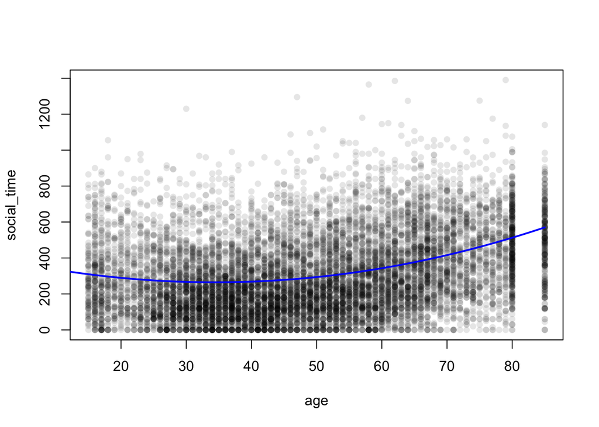

```r
dat <- data.frame(age = 0:85,
                  sex = rep("M", 86))
p3 <- predict(m3, dat)

plot(social_time ~ age, data=x, pch=16, col=rgb(0, 0, 0, 0.1))
lines(dat$age, p3, col="blue", lwd=2)
```

Quick detour discussion on `rep()`:

```r
rep(1:3, each=2)
```

```
## [1] 1 1 2 2 3 3
```

```r
rep(1:3, times=2)
```

```
## [1] 1 2 3 1 2 3
```

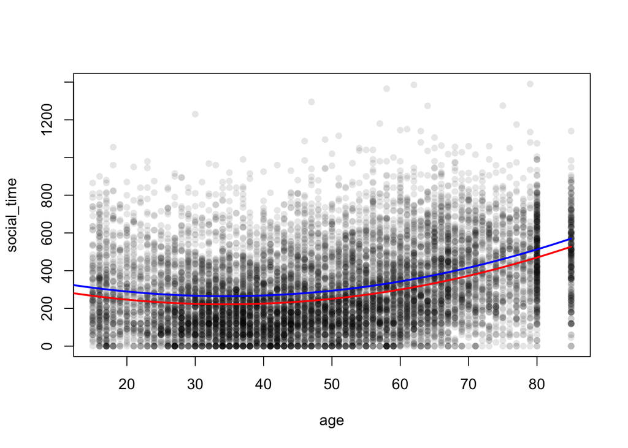

```r
dat <- data.frame(age = rep(0:85, times = 2),
                  sex = rep(c("M", "F"), each = 86))
p3 <- predict(m3, dat)

plot(social_time ~ age, data=x, pch=16, col=rgb(0, 0, 0, 0.1))
lines(dat$age[dat$sex == "M"], p3[dat$sex == "M"], col="blue", lwd=2)
lines(dat$age[dat$sex == "F"], p3[dat$sex == "F"], col="red", lwd=2)
```

```r
summary(m3)
```

```
##
## Call:
## lm(formula = social_time ~ age + I(age^2) + sex, data = x)
##
## Residuals:
##     Min      1Q  Median      3Q     Max
## -570.22 -151.16  -33.78  123.40 1054.32
##
## Coefficients:
##               Estimate Std. Error t value Pr(>|t|)
## (Intercept) 362.815423  13.405901   27.06   <2e-16 ***
## age          -8.204631   0.571816  -14.35   <2e-16 ***
## I(age^2)      0.119275   0.005673   21.03   <2e-16 ***
## sexM         43.035165   3.882096   11.09   <2e-16 ***
## ---
## Signif. codes:  0 '***' 0.001 '**' 0.01 '*' 0.05 '.' 0.1 ' ' 1
##
## Residual standard error: 203 on 11115 degrees of freedom
##   (231 observations deleted due to missingness)
## Multiple R-squared:  0.1288, Adjusted R-squared:  0.1285
## F-statistic: 547.7 on 3 and 11115 DF,  p-value: < 2.2e-16
```

Suppose we were to recode our model such that it fitted a coefficient for $sex_{Female}$, how would things change?

```r
class(x$sex)
```

```
## [1] "character"
```

```r
levels(factor(x$sex))
```

```
## [1] "F" "M"
```

The first level is “F” because of alphabetical order. In linear regression, the first level is taken to be the **baseline level**. We can force R to choose “M” to be the first level.

```r
x$sex <- factor(x$sex, levels=c("M", "F"))

m4 <- lm(social_time ~ age + I(age^2) + sex, data=x)
summary(m4)
```

```
##
## Call:
## lm(formula = social_time ~ age + I(age^2) + sex, data = x)
##
## Residuals:
##     Min      1Q  Median      3Q     Max
## -570.22 -151.16  -33.78  123.40 1054.32
##
## Coefficients:
##               Estimate Std. Error t value Pr(>|t|)
## (Intercept) 405.850587  13.494074   30.08   <2e-16 ***
## age          -8.204631   0.571816  -14.35   <2e-16 ***
## I(age^2)      0.119275   0.005673   21.03   <2e-16 ***
## sexF        -43.035165   3.882096  -11.09   <2e-16 ***
## ---
## Signif. codes:  0 '***' 0.001 '**' 0.01 '*' 0.05 '.' 0.1 ' ' 1
##
## Residual standard error: 203 on 11115 degrees of freedom
##   (231 observations deleted due to missingness)
## Multiple R-squared:  0.1288, Adjusted R-squared:  0.1285
## F-statistic: 547.7 on 3 and 11115 DF,  p-value: < 2.2e-16
```

The p-value for `sexF`. This is testing the hypotheses:

$$H_0: \beta_{sexF} = 0 \text{ vs. }H_a:\beta_{sexF} \ne 0$$

If we fail to reject $H_0$, concluding that there is no evidence suggesting $\beta_{sexF}$ is nonzero, then that is like saying there is no difference in social time between the two sexes.

## Incorporating Diary Date

```r
head(x$diary_date)
```

```
## [1] 20140126 20140130 20140127 20140126 20140129 20140126
```

```r
class(x$diary_date)
```

```
## [1] "integer"
```

A package called lubridate.

```r
#install.packages("lubridate")
library(lubridate)
x$diary_date <- ymd(x$diary_date)
head(x$diary_date)
```

```
## [1] "2014-01-26" "2014-01-30" "2014-01-27" "2014-01-26" "2014-01-29"
## [6] "2014-01-26"
```

```r
class(x$diary_date)
```

```
## [1] "Date"
```

```r
x$wday <- wday(x$diary_date)
table(x$wday)
```

```
##
##    1    2    3    4    5    6    7
## 2864 1108 1142 1122 1091 1113 2679
```

```r
x$wday <- factor(wday(x$diary_date, label=TRUE), ordered=FALSE)
table(x$wday)
```

```
##
##   Sun   Mon  Tues   Wed Thurs   Fri   Sat
##  2864  1108  1142  1122  1091  1113  2679
```

```r
class(x$wday)
```

```
## [1] "factor"
```

```r
m4 <- lm(social_time ~ age + I(age^2) + sex + wday, data=x)
summary(m4)
```

```
##
## Call:
## lm(formula = social_time ~ age + I(age^2) + sex + wday, data = x)
##
## Residuals:
##    Min     1Q Median     3Q    Max
## -576.2 -141.1  -31.1  116.1 1085.7
##
## Coefficients:
##               Estimate Std. Error t value Pr(>|t|)
## (Intercept) 445.541012  13.500230  33.002   <2e-16 ***
## age          -8.139729   0.557168 -14.609   <2e-16 ***
## I(age^2)      0.118764   0.005528  21.485   <2e-16 ***
## sexF        -42.641456   3.782602 -11.273   <2e-16 ***
## wdayMon     -86.759975   6.998111 -12.398   <2e-16 ***
## wdayTues    -93.692871   6.923076 -13.533   <2e-16 ***
## wdayWed     -91.402053   6.966500 -13.120   <2e-16 ***
## wdayThurs   -99.460546   7.037803 -14.132   <2e-16 ***
## wdayFri     -61.403509   6.986859  -8.788   <2e-16 ***
## wdaySat       7.064279   5.318063   1.328    0.184
## ---
## Signif. codes:  0 '***' 0.001 '**' 0.01 '*' 0.05 '.' 0.1 ' ' 1
##
## Residual standard error: 197.8 on 11109 degrees of freedom
##   (231 observations deleted due to missingness)
## Multiple R-squared:  0.1735, Adjusted R-squared:  0.1729
## F-statistic: 259.2 on 9 and 11109 DF,  p-value: < 2.2e-16
```

```r
head(model.matrix(m4))
```

```
##   (Intercept) age I(age^2) sexF wdayMon wdayTues wdayWed wdayThurs wdayFri
## 1           1  20      400    1       0        0       0         0       0
## 2           1  16      256    1       0        0       0         1       0
## 3           1  65     4225    1       1        0       0         0       0
## 4           1  50     2500    1       0        0       0         0       0
## 5           1  23      529    1       0        0       1         0       0
## 6           1  85     7225    0       0        0       0         0       0
##   wdaySat
## 1       0
## 2       0
## 3       0
## 4       0
## 5       0
## 6       0
```

Let’s consider modeling just a weekday vs. weekend effect, rather than breaking out exact days of the week.

```r
x$wknd <- x$wday %in% c("Sat", "Sun")
table(x$wknd, x$wday)
```

```
##
##          Sun  Mon Tues  Wed Thurs  Fri  Sat
##   FALSE    0 1108 1142 1122  1091 1113    0
##   TRUE  2864    0    0    0     0    0 2679
```

```r
m5 <- lm(social_time ~ age + I(age^2) + sex + wknd, data=x)
summary(m5)
```

```
##
## Call:
## lm(formula = social_time ~ age + I(age^2) + sex + wknd, data = x)
##
## Residuals:
##     Min      1Q  Median      3Q     Max
## -572.52 -141.03  -30.59  115.96 1078.59
##
## Coefficients:
##               Estimate Std. Error t value Pr(>|t|)
## (Intercept) 358.738978  13.305459   26.96   <2e-16 ***
## age          -8.131190   0.557637  -14.58   <2e-16 ***
## I(age^2)      0.118692   0.005532   21.45   <2e-16 ***
## sexF        -42.566350   3.785832  -11.24   <2e-16 ***
## wkndTRUE     89.952847   3.755373   23.95   <2e-16 ***
## ---
## Signif. codes:  0 '***' 0.001 '**' 0.01 '*' 0.05 '.' 0.1 ' ' 1
##
## Residual standard error: 198 on 11114 degrees of freedom
##   (231 observations deleted due to missingness)
## Multiple R-squared:  0.1716, Adjusted R-squared:  0.1713
## F-statistic: 575.4 on 4 and 11114 DF,  p-value: < 2.2e-16
```

```r
head(model.matrix(m5))
```

```
##   (Intercept) age I(age^2) sexF wkndTRUE
## 1           1  20      400    1        1
## 2           1  16      256    1        0
## 3           1  65     4225    1        0
## 4           1  50     2500    1        1
## 5           1  23      529    1        0
## 6           1  85     7225    0        1
```

Fitted equation:

$$\widehat{\text{social_time}} = 359 - 8.1 age + 0.119 age^2 - 42.6sex_{F} + 90.0 wknd$$

Males on a weekday:

$$\widehat{\text{social_time}} = 359 - 8.1 age + 0.119 age^2$$

Males on a weekend:

$$\widehat{\text{social_time}} = 449 - 8.1 age + 0.119 age^2$$

Females on a weekday:

$$\widehat{\text{social_time}} = 316.4 - 8.1 age + 0.119 age^2$$

Females on a weekend:

$$\widehat{\text{social_time}} = 406.4 - 8.1 age + 0.119 age^2$$